# Risk Factor Analysis

## Outcome Variable

**Outcome Variable:** haz

## Predictor Variables

**Intervention Variable:** enwast

**Adjustment Set:**

unadjusted

## Stratifying Variables

The analysis was stratified on these variable(s):

- agecat
- studyid
- country

## Data Summary

| agecat | studyid | country | enwast | n_cell | n |
| --- | --- | --- | --- | --- | --- |
| Birth | ki0047075b-MAL-ED | BANGLADESH | 0 | 201 | 241 |
| Birth | ki0047075b-MAL-ED | BANGLADESH | 1 | 40 | 241 |
| Birth | ki0047075b-MAL-ED | BRAZIL | 0 | 177 | 183 |
| Birth | ki0047075b-MAL-ED | BRAZIL | 1 | 6 | 183 |
| Birth | ki0047075b-MAL-ED | INDIA | 0 | 170 | 203 |
| Birth | ki0047075b-MAL-ED | INDIA | 1 | 33 | 203 |
| Birth | ki0047075b-MAL-ED | NEPAL | 0 | 148 | 169 |
| Birth | ki0047075b-MAL-ED | NEPAL | 1 | 21 | 169 |
| Birth | ki0047075b-MAL-ED | PERU | 0 | 273 | 279 |
| Birth | ki0047075b-MAL-ED | PERU | 1 | 6 | 279 |
| Birth | ki0047075b-MAL-ED | SOUTH AFRICA | 0 | 240 | 260 |
| Birth | ki0047075b-MAL-ED | SOUTH AFRICA | 1 | 20 | 260 |
| Birth | ki0047075b-MAL-ED | TANZANIA, UNITED REPUBLIC OF | 0 | 116 | 118 |
| Birth | ki0047075b-MAL-ED | TANZANIA, UNITED REPUBLIC OF | 1 | 2 | 118 |
| Birth | ki1000108-CMC-V-BCS-2002 | INDIA | 0 | 74 | 85 |
| Birth | ki1000108-CMC-V-BCS-2002 | INDIA | 1 | 11 | 85 |
| Birth | ki1000108-IRC | INDIA | 0 | 256 | 369 |
| Birth | ki1000108-IRC | INDIA | 1 | 113 | 369 |
| Birth | ki1000109-EE | PAKISTAN | 0 | 1 | 2 |
| Birth | ki1000109-EE | PAKISTAN | 1 | 1 | 2 |
| Birth | ki1000109-ResPak | PAKISTAN | 0 | 6 | 6 |
| Birth | ki1000109-ResPak | PAKISTAN | 1 | 0 | 6 |
| Birth | ki1000304b-SAS-CompFeed | INDIA | 0 | 155 | 166 |
| Birth | ki1000304b-SAS-CompFeed | INDIA | 1 | 11 | 166 |
| Birth | ki1017093-NIH-Birth | BANGLADESH | 0 | 21 | 28 |
| Birth | ki1017093-NIH-Birth | BANGLADESH | 1 | 7 | 28 |
| Birth | ki1017093c-NIH-Crypto | BANGLADESH | 0 | 20 | 23 |
| Birth | ki1017093c-NIH-Crypto | BANGLADESH | 1 | 3 | 23 |
| Birth | ki1101329-Keneba | GAMBIA | 0 | 1504 | 1537 |
| Birth | ki1101329-Keneba | GAMBIA | 1 | 33 | 1537 |

[output cut: 142 more lines]

The following strata were considered:

- agecat: 24 months, studyid: ki0047075b-MAL-ED, country: BANGLADESH
- agecat: 24 months, studyid: ki0047075b-MAL-ED, country: BRAZIL
- agecat: 24 months, studyid: ki0047075b-MAL-ED, country: INDIA
- agecat: 24 months, studyid: ki0047075b-MAL-ED, country: NEPAL
- agecat: 24 months, studyid: ki0047075b-MAL-ED, country: PERU
- agecat: 24 months, studyid: ki0047075b-MAL-ED, country: SOUTH AFRICA
- agecat: 24 months, studyid: ki0047075b-MAL-ED, country: TANZANIA, UNITED REPUBLIC OF
- agecat: 24 months, studyid: ki1000108-CMC-V-BCS-2002, country: INDIA
- agecat: 24 months, studyid: ki1000108-IRC, country: INDIA
- agecat: 24 months, studyid: ki1017093-NIH-Birth, country: BANGLADESH
- agecat: 24 months, studyid: ki1017093b-PROVIDE, country: BANGLADESH
- agecat: 24 months, studyid: ki1017093c-NIH-Crypto, country: BANGLADESH
- agecat: 24 months, studyid: ki1066203-TanzaniaChild2, country: TANZANIA, UNITED REPUBLIC OF
- agecat: 24 months, studyid: ki1101329-Keneba, country: GAMBIA
- agecat: 24 months, studyid: ki1113344-GMS-Nepal, country: NEPAL
- agecat: 24 months, studyid: ki1114097-CMIN, country: BANGLADESH
- agecat: 24 months, studyid: ki1114097-CMIN, country: GUINEA-BISSAU
- agecat: 24 months, studyid: ki1114097-CMIN, country: PERU
- agecat: 24 months, studyid: ki1114097-CONTENT, country: PERU
- agecat: 24 months, studyid: ki1119695-PROBIT, country: BELARUS
- agecat: 24 months, studyid: ki1126311-ZVITAMBO, country: ZIMBABWE
- agecat: 24 months, studyid: ki1135781-COHORTS, country: GUATEMALA
- agecat: 24 months, studyid: ki1135781-COHORTS, country: INDIA
- agecat: 24 months, studyid: ki1135781-COHORTS, country: PHILIPPINES
- agecat: 24 months, studyid: ki1148112-LCNI-5, country: MALAWI
- agecat: 24 months, studyid: kiGH5241-JiVitA-3, country: BANGLADESH
- agecat: 24 months, studyid: kiGH5241-JiVitA-4, country: BANGLADESH
- agecat: 6 months, studyid: ki0047075b-MAL-ED, country: BANGLADESH
- agecat: 6 months, studyid: ki0047075b-MAL-ED, country: BRAZIL
- agecat: 6 months, studyid: ki0047075b-MAL-ED, country: INDIA
- agecat: 6 months, studyid: ki0047075b-MAL-ED, country: NEPAL
- agecat: 6 months, studyid: ki0047075b-MAL-ED, country: PERU
- agecat: 6 months, studyid: ki0047075b-MAL-ED, country: SOUTH AFRICA
- agecat: 6 months, studyid: ki0047075b-MAL-ED, country: TANZANIA, UNITED REPUBLIC OF
- agecat: 6 months, studyid: ki1000108-CMC-V-BCS-2002, country: INDIA
- agecat: 6 months, studyid: ki1000108-IRC, country: INDIA
- agecat: 6 months, studyid: ki1000109-EE, country: PAKISTAN
- agecat: 6 months, studyid: ki1000109-ResPak, country: PAKISTAN
- agecat: 6 months, studyid: ki1000304b-SAS-CompFeed, country: INDIA
- agecat: 6 months, studyid: ki1000304b-SAS-FoodSuppl, country: INDIA
- agecat: 6 months, studyid: ki1017093-NIH-Birth, country: BANGLADESH
- agecat: 6 months, studyid: ki1017093b-PROVIDE, country: BANGLADESH
- agecat: 6 months, studyid: ki1017093c-NIH-Crypto, country: BANGLADESH
- agecat: 6 months, studyid: ki1066203-TanzaniaChild2, country: TANZANIA, UNITED REPUBLIC OF
- agecat: 6 months, studyid: ki1101329-Keneba, country: GAMBIA
- agecat: 6 months, studyid: ki1112895-Guatemala BSC, country: GUATEMALA
- agecat: 6 months, studyid: ki1113344-GMS-Nepal, country: NEPAL
- agecat: 6 months, studyid: ki1114097-CMIN, country: BANGLADESH
- agecat: 6 months, studyid: ki1114097-CMIN, country: BRAZIL
- agecat: 6 months, studyid: ki1114097-CMIN, country: GUINEA-BISSAU
- agecat: 6 months, studyid: ki1114097-CMIN, country: PERU
- agecat: 6 months, studyid: ki1114097-CONTENT, country: PERU
- agecat: 6 months, studyid: ki1119695-PROBIT, country: BELARUS
- agecat: 6 months, studyid: ki1126311-ZVITAMBO, country: ZIMBABWE
- agecat: 6 months, studyid: ki1135781-COHORTS, country: GUATEMALA
- agecat: 6 months, studyid: ki1135781-COHORTS, country: INDIA
- agecat: 6 months, studyid: ki1135781-COHORTS, country: PHILIPPINES
- agecat: 6 months, studyid: ki1148112-LCNI-5, country: MALAWI
- agecat: 6 months, studyid: kiGH5241-JiVitA-3, country: BANGLADESH
- agecat: 6 months, studyid: kiGH5241-JiVitA-4, country: BANGLADESH
- agecat: Birth, studyid: ki0047075b-MAL-ED, country: BANGLADESH
- agecat: Birth, studyid: ki0047075b-MAL-ED, country: BRAZIL
- agecat: Birth, studyid: ki0047075b-MAL-ED, country: INDIA
- agecat: Birth, studyid: ki0047075b-MAL-ED, country: NEPAL
- agecat: Birth, studyid: ki0047075b-MAL-ED, country: PERU
- agecat: Birth, studyid: ki0047075b-MAL-ED, country: SOUTH AFRICA
- agecat: Birth, studyid: ki0047075b-MAL-ED, country: TANZANIA, UNITED REPUBLIC OF
- agecat: Birth, studyid: ki1000108-CMC-V-BCS-2002, country: INDIA
- agecat: Birth, studyid: ki1000108-IRC, country: INDIA
- agecat: Birth, studyid: ki1000109-EE, country: PAKISTAN
- agecat: Birth, studyid: ki1000109-ResPak, country: PAKISTAN
- agecat: Birth, studyid: ki1000304b-SAS-CompFeed, country: INDIA
- agecat: Birth, studyid: ki1017093-NIH-Birth, country: BANGLADESH
- agecat: Birth, studyid: ki1017093c-NIH-Crypto, country: BANGLADESH
- agecat: Birth, studyid: ki1101329-Keneba, country: GAMBIA
- agecat: Birth, studyid: ki1114097-CMIN, country: BANGLADESH
- agecat: Birth, studyid: ki1114097-CMIN, country: BRAZIL
- agecat: Birth, studyid: ki1114097-CMIN, country: PERU
- agecat: Birth, studyid: ki1114097-CONTENT, country: PERU
- agecat: Birth, studyid: ki1119695-PROBIT, country: BELARUS
- agecat: Birth, studyid: ki1126311-ZVITAMBO, country: ZIMBABWE
- agecat: Birth, studyid: ki1135781-COHORTS, country: GUATEMALA
- agecat: Birth, studyid: ki1135781-COHORTS, country: INDIA
- agecat: Birth, studyid: ki1135781-COHORTS, country: PHILIPPINES
- agecat: Birth, studyid: kiGH5241-JiVitA-3, country: BANGLADESH
- agecat: Birth, studyid: kiGH5241-JiVitA-4, country: BANGLADESH

### Dropped Strata

Some strata were dropped due to rare outcomes:

- agecat: Birth, studyid: ki0047075b-MAL-ED, country: TANZANIA, UNITED REPUBLIC OF
- agecat: Birth, studyid: ki1000109-EE, country: PAKISTAN
- agecat: Birth, studyid: ki1000109-ResPak, country: PAKISTAN
- agecat: Birth, studyid: ki1017093c-NIH-Crypto, country: BANGLADESH
- agecat: Birth, studyid: ki1114097-CMIN, country: BANGLADESH
- agecat: Birth, studyid: ki1114097-CMIN, country: PERU
- agecat: Birth, studyid: ki1114097-CONTENT, country: PERU
- agecat: 6 months, studyid: ki0047075b-MAL-ED, country: TANZANIA, UNITED REPUBLIC OF
- agecat: 6 months, studyid: ki1114097-CONTENT, country: PERU
- agecat: 24 months, studyid: ki0047075b-MAL-ED, country: PERU
- agecat: 24 months, studyid: ki0047075b-MAL-ED, country: TANZANIA, UNITED REPUBLIC OF
- agecat: 24 months, studyid: ki1066203-TanzaniaChild2, country: TANZANIA, UNITED REPUBLIC OF
- agecat: 24 months, studyid: ki1114097-CONTENT, country: PERU

## Methods Detail

We’re interested in the causal parameters $E[Y_a]$ for all values of $a \in \mathcal{A}$. These parameters represent the mean outcome if, possibly contrary to fact, we intervened to set all units to have $A=a$. Under the randomization and positivity assumptions, these are identified by the statistical parameters $\psi_a=E_W[E_{Y|A,W}(Y|A=a,W)]$. In addition, we’re interested in the mean of $Y$, $E[Y]$ under no intervention (the observed mean). We will estimate these parameters by using SuperLearner to fit the relevant likelihood factors – $E_{Y|A,W}(Y|A=a,W)$ and $p(A=a|W)$, and then updating our likelihood fit using a joint TMLE.

For unadjusted analyses ($W=\{\}$), initial likelihoods were estimated using Lrnr_glm to estimate the simple $E(Y|A)$ and Lrnr_mean to estimate $p(A)$. For adjusted analyses, a small library containing Lrnr_glmnet, Lrnr_xgboost, and Lrnr_mean was used.

Having estimated these parameters, we will then use the delta method to estimate relative risks and attributable risks relative to a prespecified baseline level of $A$.

# Results Detail

## Results Plots

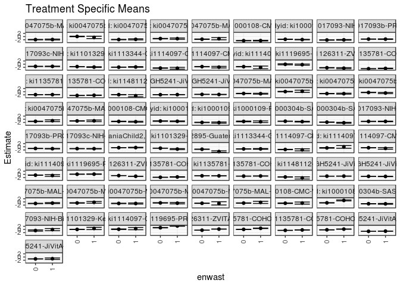

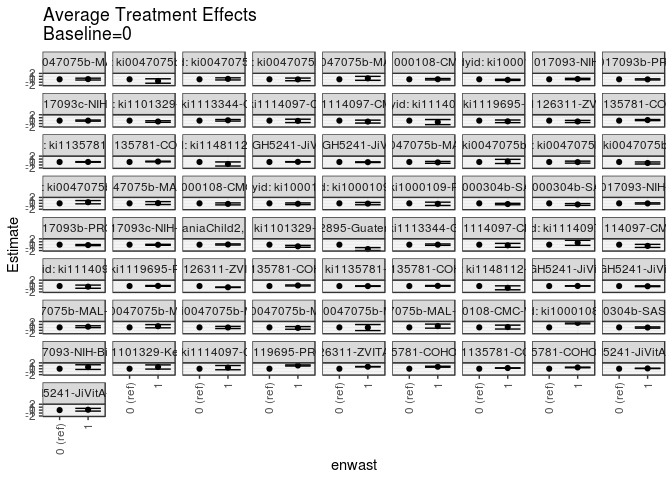

[figure not shown]

## Results Table

### Parameter: TSM

| agecat | studyid | country | intervention_level | baseline_level | estimate | ci_lower | ci_upper |
| --- | --- | --- | --- | --- | --- | --- | --- |
| Birth | ki0047075b-MAL-ED | BANGLADESH | 0 | NA | -0.9831343 | -1.1026895 | -0.8635792 |
| Birth | ki0047075b-MAL-ED | BANGLADESH | 1 | NA | -0.7437500 | -1.0434224 | -0.4440776 |
| Birth | ki0047075b-MAL-ED | BRAZIL | 0 | NA | -0.6676836 | -0.8118231 | -0.5235442 |
| Birth | ki0047075b-MAL-ED | BRAZIL | 1 | NA | -0.2666667 | -0.8014912 | 0.2681579 |
| Birth | ki0047075b-MAL-ED | INDIA | 0 | NA | -0.9623529 | -1.1061891 | -0.8185168 |
| Birth | ki0047075b-MAL-ED | INDIA | 1 | NA | -0.9912121 | -1.3280802 | -0.6543441 |
| Birth | ki0047075b-MAL-ED | NEPAL | 0 | NA | -0.6150676 | -0.7672129 | -0.4629222 |
| Birth | ki0047075b-MAL-ED | NEPAL | 1 | NA | -0.7947619 | -1.2163301 | -0.3731937 |
| Birth | ki0047075b-MAL-ED | PERU | 0 | NA | -0.8557509 | -0.9580036 | -0.7534983 |
| Birth | ki0047075b-MAL-ED | PERU | 1 | NA | -0.9100000 | -1.9335967 | 0.1135967 |
| Birth | ki0047075b-MAL-ED | SOUTH AFRICA | 0 | NA | -0.7266250 | -0.8430832 | -0.6101668 |
| Birth | ki0047075b-MAL-ED | SOUTH AFRICA | 1 | NA | -0.2985000 | -0.9825911 | 0.3855911 |
| Birth | ki1000108-CMC-V-BCS-2002 | INDIA | 0 | NA | -0.8340541 | -1.0101939 | -0.6579142 |
| Birth | ki1000108-CMC-V-BCS-2002 | INDIA | 1 | NA | -0.7300000 | -1.3758269 | -0.0841731 |
| Birth | ki1000108-IRC | INDIA | 0 | NA | -0.5842187 | -0.7065982 | -0.4618393 |
| Birth | ki1000108-IRC | INDIA | 1 | NA | 0.9509735 | 0.6637078 | 1.2382391 |
| Birth | ki1000304b-SAS-CompFeed | INDIA | 0 | NA | -1.1557419 | -1.2600514 | -1.0514324 |
| Birth | ki1000304b-SAS-CompFeed | INDIA | 1 | NA | -1.2036364 | -1.4458859 | -0.9613868 |
| Birth | ki1017093-NIH-Birth | BANGLADESH | 0 | NA | -0.6704762 | -1.0619720 | -0.2789804 |
| Birth | ki1017093-NIH-Birth | BANGLADESH | 1 | NA | -0.1057143 | -0.7959107 | 0.5844821 |
| Birth | ki1101329-Keneba | GAMBIA | 0 | NA | 0.0314561 | -0.0302306 | 0.0931428 |
| Birth | ki1101329-Keneba | GAMBIA | 1 | NA | 0.6293939 | -0.0823704 | 1.3411583 |
| Birth | ki1114097-CMIN | BRAZIL | 0 | NA | 0.1498058 | -0.0291164 | 0.3287280 |
| Birth | ki1114097-CMIN | BRAZIL | 1 | NA | 0.5275000 | -0.1719603 | 1.2269603 |
| Birth | ki1119695-PROBIT | BELARUS | 0 | NA | 1.0911860 | 0.9846031 | 1.1977688 |
| Birth | ki1119695-PROBIT | BELARUS | 1 | NA | 2.2076675 | 2.0322390 | 2.3830959 |
| Birth | ki1126311-ZVITAMBO | ZIMBABWE | 0 | NA | -0.4607185 | -0.4783293 | -0.4431077 |
| Birth | ki1126311-ZVITAMBO | ZIMBABWE | 1 | NA | 0.2389893 | 0.1837843 | 0.2941943 |
| Birth | ki1135781-COHORTS | GUATEMALA | 0 | NA | 0.0463298 | -0.0424159 | 0.1350755 |
| Birth | ki1135781-COHORTS | GUATEMALA | 1 | NA | 0.7225253 | 0.5787376 | 0.8663129 |

[output cut: 116 more lines]

### Parameter: E(Y)

| agecat | studyid | country | intervention_level | baseline_level | estimate | ci_lower | ci_upper |
| --- | --- | --- | --- | --- | --- | --- | --- |
| Birth | ki0047075b-MAL-ED | BANGLADESH | NA | NA | -0.9434025 | -1.0553995 | -0.8314055 |
| Birth | ki0047075b-MAL-ED | BRAZIL | NA | NA | -0.6545355 | -0.7954300 | -0.5136410 |
| Birth | ki0047075b-MAL-ED | INDIA | NA | NA | -0.9670443 | -1.0993703 | -0.8347184 |
| Birth | ki0047075b-MAL-ED | NEPAL | NA | NA | -0.6373964 | -0.7808443 | -0.4939486 |
| Birth | ki0047075b-MAL-ED | PERU | NA | NA | -0.8569176 | -0.9598499 | -0.7539853 |
| Birth | ki0047075b-MAL-ED | SOUTH AFRICA | NA | NA | -0.6936923 | -0.8141845 | -0.5732001 |
| Birth | ki1000108-CMC-V-BCS-2002 | INDIA | NA | NA | -0.8205882 | -0.9953903 | -0.6457861 |
| Birth | ki1000108-IRC | INDIA | NA | NA | -0.1140921 | -0.2561277 | 0.0279434 |
| Birth | ki1000304b-SAS-CompFeed | INDIA | NA | NA | -1.1589157 | -1.2666273 | -1.0512040 |
| Birth | ki1017093-NIH-Birth | BANGLADESH | NA | NA | -0.5292857 | -0.8821252 | -0.1764462 |
| Birth | ki1101329-Keneba | GAMBIA | NA | NA | 0.0442941 | -0.0185771 | 0.1071652 |
| Birth | ki1114097-CMIN | BRAZIL | NA | NA | 0.1770270 | 0.0025580 | 0.3514960 |
| Birth | ki1119695-PROBIT | BELARUS | NA | NA | 1.3278057 | 1.1691020 | 1.4865095 |
| Birth | ki1126311-ZVITAMBO | ZIMBABWE | NA | NA | -0.3412145 | -0.3591726 | -0.3232564 |
| Birth | ki1135781-COHORTS | GUATEMALA | NA | NA | 0.2220341 | 0.1435838 | 0.3004845 |
| Birth | ki1135781-COHORTS | INDIA | NA | NA | -0.5071369 | -0.5319444 | -0.4823294 |
| Birth | ki1135781-COHORTS | PHILIPPINES | NA | NA | -0.1490962 | -0.1843045 | -0.1138879 |
| Birth | kiGH5241-JiVitA-3 | BANGLADESH | NA | NA | -1.1673153 | -1.1822647 | -1.1523660 |
| Birth | kiGH5241-JiVitA-4 | BANGLADESH | NA | NA | -1.1775403 | -1.2476425 | -1.1074380 |
| 6 months | ki0047075b-MAL-ED | BANGLADESH | NA | NA | -1.1553785 | -1.2731711 | -1.0375858 |
| 6 months | ki0047075b-MAL-ED | BRAZIL | NA | NA | 0.0784818 | -0.0680282 | 0.2249919 |
| 6 months | ki0047075b-MAL-ED | INDIA | NA | NA | -1.2047496 | -1.3231151 | -1.0863842 |
| 6 months | ki0047075b-MAL-ED | NEPAL | NA | NA | -0.5342241 | -0.6451165 | -0.4233318 |
| 6 months | ki0047075b-MAL-ED | PERU | NA | NA | -1.3033145 | -1.4123055 | -1.1943235 |
| 6 months | ki0047075b-MAL-ED | SOUTH AFRICA | NA | NA | -1.0492984 | -1.1745095 | -0.9240873 |
| 6 months | ki1000108-CMC-V-BCS-2002 | INDIA | NA | NA | -1.4223508 | -1.5654032 | -1.2792984 |
| 6 months | ki1000108-IRC | INDIA | NA | NA | -1.1884152 | -1.3196342 | -1.0571962 |
| 6 months | ki1000109-EE | PAKISTAN | NA | NA | -2.0046626 | -2.1248969 | -1.8844282 |
| 6 months | ki1000109-ResPak | PAKISTAN | NA | NA | -1.4026180 | -1.6123162 | -1.1929198 |
| 6 months | ki1000304b-SAS-CompFeed | INDIA | NA | NA | -1.2781121 | -1.3694457 | -1.1867786 |
| 6 months | ki1000304b-SAS-FoodSuppl | INDIA | NA | NA | -1.8986842 | -2.0118892 | -1.7854792 |
| 6 months | ki1017093-NIH-Birth | BANGLADESH | NA | NA | -1.3447001 | -1.4316348 | -1.2577653 |
| 6 months | ki1017093b-PROVIDE | BANGLADESH | NA | NA | -1.0675376 | -1.1432331 | -0.9918422 |
| 6 months | ki1017093c-NIH-Crypto | BANGLADESH | NA | NA | -1.1560014 | -1.2261266 | -1.0858763 |
| 6 months | ki1066203-TanzaniaChild2 | TANZANIA, UNITED REPUBLIC OF | NA | NA | -0.5424220 | -0.5912180 | -0.4936261 |
| 6 months | ki1101329-Keneba | GAMBIA | NA | NA | -0.8963775 | -0.9433248 | -0.8494302 |
| 6 months | ki1112895-Guatemala BSC | GUATEMALA | NA | NA | -1.5619008 | -1.6727702 | -1.4510313 |
| 6 months | ki1113344-GMS-Nepal | NEPAL | NA | NA | -1.3262953 | -1.4042959 | -1.2482948 |
| 6 months | ki1114097-CMIN | BANGLADESH | NA | NA | -1.7090230 | -1.8439050 | -1.5741410 |
| 6 months | ki1114097-CMIN | BRAZIL | NA | NA | -0.6480000 | -0.8487905 | -0.4472095 |
| 6 months | ki1114097-CMIN | GUINEA-BISSAU | NA | NA | -0.5979325 | -0.6732517 | -0.5226132 |
| 6 months | ki1114097-CMIN | PERU | NA | NA | -0.5132548 | -0.5926717 | -0.4338380 |
| 6 months | ki1119695-PROBIT | BELARUS | NA | NA | 0.1076416 | 0.0130507 | 0.2022324 |
| 6 months | ki1126311-ZVITAMBO | ZIMBABWE | NA | NA | -0.8394653 | -0.8656101 | -0.8133205 |
| 6 months | ki1135781-COHORTS | GUATEMALA | NA | NA | -1.7950277 | -1.8646284 | -1.7254271 |
| 6 months | ki1135781-COHORTS | INDIA | NA | NA | -0.9241887 | -0.9514678 | -0.8969095 |
| 6 months | ki1135781-COHORTS | PHILIPPINES | NA | NA | -1.0928731 | -1.1347142 | -1.0510321 |
| 6 months | ki1148112-LCNI-5 | MALAWI | NA | NA | -1.6601907 | -1.7297701 | -1.5906113 |
| 6 months | kiGH5241-JiVitA-3 | BANGLADESH | NA | NA | -1.1247577 | -1.1475519 | -1.1019635 |
| 6 months | kiGH5241-JiVitA-4 | BANGLADESH | NA | NA | -1.2460635 | -1.2827993 | -1.2093277 |
| 24 months | ki0047075b-MAL-ED | BANGLADESH | NA | NA | -1.8962687 | -2.0241450 | -1.7683923 |
| 24 months | ki0047075b-MAL-ED | BRAZIL | NA | NA | 0.0696012 | -0.0999839 | 0.2391864 |
| 24 months | ki0047075b-MAL-ED | INDIA | NA | NA | -1.8363616 | -1.9636359 | -1.7090873 |
| 24 months | ki0047075b-MAL-ED | NEPAL | NA | NA | -1.2619556 | -1.3827787 | -1.1411324 |
| 24 months | ki0047075b-MAL-ED | SOUTH AFRICA | NA | NA | -1.6216878 | -1.7575225 | -1.4858530 |
| 24 months | ki1000108-CMC-V-BCS-2002 | INDIA | NA | NA | -2.5564429 | -2.6570768 | -2.4558090 |
| 24 months | ki1000108-IRC | INDIA | NA | NA | -1.7623926 | -1.8591106 | -1.6656746 |
| 24 months | ki1017093-NIH-Birth | BANGLADESH | NA | NA | -2.1194886 | -2.2222242 | -2.0167530 |
| 24 months | ki1017093b-PROVIDE | BANGLADESH | NA | NA | -1.5715641 | -1.6543870 | -1.4887413 |
| 24 months | ki1017093c-NIH-Crypto | BANGLADESH | NA | NA | -1.4004800 | -1.4835266 | -1.3174334 |
| 24 months | ki1101329-Keneba | GAMBIA | NA | NA | -1.5586932 | -1.6085568 | -1.5088295 |
| 24 months | ki1113344-GMS-Nepal | NEPAL | NA | NA | -1.8761201 | -1.9601745 | -1.7920656 |
| 24 months | ki1114097-CMIN | BANGLADESH | NA | NA | -2.4877155 | -2.6168325 | -2.3585986 |
| 24 months | ki1114097-CMIN | GUINEA-BISSAU | NA | NA | -1.5673266 | -1.6667006 | -1.4679527 |
| 24 months | ki1114097-CMIN | PERU | NA | NA | -1.5807226 | -1.6772768 | -1.4841684 |
| 24 months | ki1119695-PROBIT | BELARUS | NA | NA | -0.1311901 | -0.4268581 | 0.1644779 |
| 24 months | ki1126311-ZVITAMBO | ZIMBABWE | NA | NA | -2.2965664 | -2.4199830 | -2.1731498 |
| 24 months | ki1135781-COHORTS | GUATEMALA | NA | NA | -2.8596404 | -2.9251693 | -2.7941116 |
| 24 months | ki1135781-COHORTS | INDIA | NA | NA | -1.8596470 | -1.8926187 | -1.8266754 |
| 24 months | ki1135781-COHORTS | PHILIPPINES | NA | NA | -2.3603707 | -2.4055731 | -2.3151683 |
| 24 months | ki1148112-LCNI-5 | MALAWI | NA | NA | -1.8754404 | -1.9564117 | -1.7944692 |
| 24 months | kiGH5241-JiVitA-3 | BANGLADESH | NA | NA | -1.8752232 | -1.9042428 | -1.8462036 |
| 24 months | kiGH5241-JiVitA-4 | BANGLADESH | NA | NA | -1.6962457 | -1.7323673 | -1.6601241 |

### Parameter: ATE

| agecat | studyid | country | intervention_level | baseline_level | estimate | ci_lower | ci_upper |
| --- | --- | --- | --- | --- | --- | --- | --- |
| Birth | ki0047075b-MAL-ED | BANGLADESH | 0 | 0 | 0.0000000 | 0.0000000 | 0.0000000 |
| Birth | ki0047075b-MAL-ED | BANGLADESH | 1 | 0 | 0.2393843 | -0.0832563 | 0.5620250 |
| Birth | ki0047075b-MAL-ED | BRAZIL | 0 | 0 | 0.0000000 | 0.0000000 | 0.0000000 |
| Birth | ki0047075b-MAL-ED | BRAZIL | 1 | 0 | 0.4010169 | -0.1528905 | 0.9549244 |
| Birth | ki0047075b-MAL-ED | INDIA | 0 | 0 | 0.0000000 | 0.0000000 | 0.0000000 |
| Birth | ki0047075b-MAL-ED | INDIA | 1 | 0 | -0.0288592 | -0.3951500 | 0.3374316 |
| Birth | ki0047075b-MAL-ED | NEPAL | 0 | 0 | 0.0000000 | 0.0000000 | 0.0000000 |
| Birth | ki0047075b-MAL-ED | NEPAL | 1 | 0 | -0.1796943 | -0.6278772 | 0.2684886 |
| Birth | ki0047075b-MAL-ED | PERU | 0 | 0 | 0.0000000 | 0.0000000 | 0.0000000 |
| Birth | ki0047075b-MAL-ED | PERU | 1 | 0 | -0.0542491 | -1.0829404 | 0.9744422 |
| Birth | ki0047075b-MAL-ED | SOUTH AFRICA | 0 | 0 | 0.0000000 | 0.0000000 | 0.0000000 |
| Birth | ki0047075b-MAL-ED | SOUTH AFRICA | 1 | 0 | 0.4281250 | -0.2658081 | 1.1220581 |
| Birth | ki1000108-CMC-V-BCS-2002 | INDIA | 0 | 0 | 0.0000000 | 0.0000000 | 0.0000000 |
| Birth | ki1000108-CMC-V-BCS-2002 | INDIA | 1 | 0 | 0.1040541 | -0.5653618 | 0.7734699 |
| Birth | ki1000108-IRC | INDIA | 0 | 0 | 0.0000000 | 0.0000000 | 0.0000000 |
| Birth | ki1000108-IRC | INDIA | 1 | 0 | 1.5351922 | 1.2229451 | 1.8474393 |
| Birth | ki1000304b-SAS-CompFeed | INDIA | 0 | 0 | 0.0000000 | 0.0000000 | 0.0000000 |
| Birth | ki1000304b-SAS-CompFeed | INDIA | 1 | 0 | -0.0478944 | -0.2523024 | 0.1565136 |
| Birth | ki1017093-NIH-Birth | BANGLADESH | 0 | 0 | 0.0000000 | 0.0000000 | 0.0000000 |
| Birth | ki1017093-NIH-Birth | BANGLADESH | 1 | 0 | 0.5647619 | -0.2287367 | 1.3582605 |
| Birth | ki1101329-Keneba | GAMBIA | 0 | 0 | 0.0000000 | 0.0000000 | 0.0000000 |
| Birth | ki1101329-Keneba | GAMBIA | 1 | 0 | 0.5979378 | -0.1164946 | 1.3123703 |
| Birth | ki1114097-CMIN | BRAZIL | 0 | 0 | 0.0000000 | 0.0000000 | 0.0000000 |
| Birth | ki1114097-CMIN | BRAZIL | 1 | 0 | 0.3776942 | -0.3442877 | 1.0996761 |
| Birth | ki1119695-PROBIT | BELARUS | 0 | 0 | 0.0000000 | 0.0000000 | 0.0000000 |
| Birth | ki1119695-PROBIT | BELARUS | 1 | 0 | 1.1164815 | 0.9335494 | 1.2994136 |
| Birth | ki1126311-ZVITAMBO | ZIMBABWE | 0 | 0 | 0.0000000 | 0.0000000 | 0.0000000 |
| Birth | ki1126311-ZVITAMBO | ZIMBABWE | 1 | 0 | 0.6997078 | 0.6417618 | 0.7576537 |
| Birth | ki1135781-COHORTS | GUATEMALA | 0 | 0 | 0.0000000 | 0.0000000 | 0.0000000 |
| Birth | ki1135781-COHORTS | GUATEMALA | 1 | 0 | 0.6761955 | 0.5072260 | 0.8451650 |

[output cut: 116 more lines]

### Parameter: PAR

| agecat | studyid | country | intervention_level | baseline_level | estimate | ci_lower | ci_upper |
| --- | --- | --- | --- | --- | --- | --- | --- |
| Birth | ki0047075b-MAL-ED | BANGLADESH | 0 | NA | 0.0397318 | -0.0149912 | 0.0944548 |
| Birth | ki0047075b-MAL-ED | BRAZIL | 0 | NA | 0.0131481 | -0.0077674 | 0.0340636 |
| Birth | ki0047075b-MAL-ED | INDIA | 0 | NA | -0.0046914 | -0.0642543 | 0.0548715 |
| Birth | ki0047075b-MAL-ED | NEPAL | 0 | NA | -0.0223289 | -0.0787370 | 0.0340792 |
| Birth | ki0047075b-MAL-ED | PERU | 0 | NA | -0.0011666 | -0.0269006 | 0.0245673 |
| Birth | ki0047075b-MAL-ED | SOUTH AFRICA | 0 | NA | 0.0329327 | -0.0222253 | 0.0880907 |
| Birth | ki1000108-CMC-V-BCS-2002 | INDIA | 0 | NA | 0.0134658 | -0.0734858 | 0.1004175 |
| Birth | ki1000108-IRC | INDIA | 0 | NA | 0.4701266 | 0.3502512 | 0.5900020 |
| Birth | ki1000304b-SAS-CompFeed | INDIA | 0 | NA | -0.0031737 | -0.0169668 | 0.0106193 |
| Birth | ki1017093-NIH-Birth | BANGLADESH | 0 | NA | 0.1411905 | -0.0775816 | 0.3599626 |
| Birth | ki1101329-Keneba | GAMBIA | 0 | NA | 0.0128380 | -0.0055412 | 0.0312171 |
| Birth | ki1114097-CMIN | BRAZIL | 0 | NA | 0.0272212 | -0.0279221 | 0.0823645 |
| Birth | ki1119695-PROBIT | BELARUS | 0 | NA | 0.2366197 | 0.1399585 | 0.3332810 |
| Birth | ki1126311-ZVITAMBO | ZIMBABWE | 0 | NA | 0.1195040 | 0.1086279 | 0.1303802 |
| Birth | ki1135781-COHORTS | GUATEMALA | 0 | NA | 0.1757043 | 0.1270053 | 0.2244034 |
| Birth | ki1135781-COHORTS | INDIA | 0 | NA | 0.0444582 | 0.0314516 | 0.0574647 |
| Birth | ki1135781-COHORTS | PHILIPPINES | 0 | NA | 0.0693515 | 0.0508996 | 0.0878034 |
| Birth | kiGH5241-JiVitA-3 | BANGLADESH | 0 | NA | 0.0106668 | 0.0053410 | 0.0159925 |
| Birth | kiGH5241-JiVitA-4 | BANGLADESH | 0 | NA | 0.0062619 | -0.0187761 | 0.0312999 |
| 6 months | ki0047075b-MAL-ED | BANGLADESH | 0 | NA | -0.0242792 | -0.0807898 | 0.0322314 |
| 6 months | ki0047075b-MAL-ED | BRAZIL | 0 | NA | 0.0064562 | -0.0184194 | 0.0313318 |
| 6 months | ki0047075b-MAL-ED | INDIA | 0 | NA | -0.0070640 | -0.0645712 | 0.0504433 |
| 6 months | ki0047075b-MAL-ED | NEPAL | 0 | NA | -0.0390046 | -0.0821920 | 0.0041828 |
| 6 months | ki0047075b-MAL-ED | PERU | 0 | NA | 0.0072282 | -0.0079937 | 0.0224502 |
| 6 months | ki0047075b-MAL-ED | SOUTH AFRICA | 0 | NA | 0.0057334 | -0.0275912 | 0.0390579 |
| 6 months | ki1000108-CMC-V-BCS-2002 | INDIA | 0 | NA | -0.0509661 | -0.1409415 | 0.0390094 |
| 6 months | ki1000108-IRC | INDIA | 0 | NA | -0.0484412 | -0.1450183 | 0.0481359 |
| 6 months | ki1000109-EE | PAKISTAN | 0 | NA | -0.0092544 | -0.0480159 | 0.0295070 |
| 6 months | ki1000109-ResPak | PAKISTAN | 0 | NA | -0.0315160 | -0.1383644 | 0.0753324 |
| 6 months | ki1000304b-SAS-CompFeed | INDIA | 0 | NA | -0.0276885 | -0.0606150 | 0.0052381 |
| 6 months | ki1000304b-SAS-FoodSuppl | INDIA | 0 | NA | -0.0694559 | -0.1276582 | -0.0112536 |
| 6 months | ki1017093-NIH-Birth | BANGLADESH | 0 | NA | -0.0066589 | -0.0645446 | 0.0512269 |
| 6 months | ki1017093b-PROVIDE | BANGLADESH | 0 | NA | -0.0273042 | -0.0677426 | 0.0131342 |
| 6 months | ki1017093c-NIH-Crypto | BANGLADESH | 0 | NA | -0.0088987 | -0.0515665 | 0.0337690 |
| 6 months | ki1066203-TanzaniaChild2 | TANZANIA, UNITED REPUBLIC OF | 0 | NA | 0.0043406 | -0.0072217 | 0.0159030 |
| 6 months | ki1101329-Keneba | GAMBIA | 0 | NA | -0.0210787 | -0.0338366 | -0.0083207 |
| 6 months | ki1112895-Guatemala BSC | GUATEMALA | 0 | NA | -0.0297734 | -0.0564518 | -0.0030950 |
| 6 months | ki1113344-GMS-Nepal | NEPAL | 0 | NA | 0.0016125 | -0.0371504 | 0.0403754 |
| 6 months | ki1114097-CMIN | BANGLADESH | 0 | NA | -0.0131591 | -0.0543214 | 0.0280032 |
| 6 months | ki1114097-CMIN | BRAZIL | 0 | NA | 0.0423061 | -0.0230784 | 0.1076906 |
| 6 months | ki1114097-CMIN | GUINEA-BISSAU | 0 | NA | -0.0108096 | -0.0251594 | 0.0035402 |
| 6 months | ki1114097-CMIN | PERU | 0 | NA | -0.0108251 | -0.0384534 | 0.0168032 |
| 6 months | ki1119695-PROBIT | BELARUS | 0 | NA | 0.0094284 | -0.0148506 | 0.0337074 |
| 6 months | ki1126311-ZVITAMBO | ZIMBABWE | 0 | NA | -0.0657398 | -0.0777057 | -0.0537739 |
| 6 months | ki1135781-COHORTS | GUATEMALA | 0 | NA | 0.0389447 | 0.0057065 | 0.0721829 |
| 6 months | ki1135781-COHORTS | INDIA | 0 | NA | -0.0035548 | -0.0171501 | 0.0100404 |
| 6 months | ki1135781-COHORTS | PHILIPPINES | 0 | NA | 0.0093998 | -0.0094680 | 0.0282676 |
| 6 months | ki1148112-LCNI-5 | MALAWI | 0 | NA | -0.0100695 | -0.0277488 | 0.0076098 |
| 6 months | kiGH5241-JiVitA-3 | BANGLADESH | 0 | NA | 0.0027256 | -0.0040980 | 0.0095493 |
| 6 months | kiGH5241-JiVitA-4 | BANGLADESH | 0 | NA | -0.0058964 | -0.0171967 | 0.0054039 |
| 24 months | ki0047075b-MAL-ED | BANGLADESH | 0 | NA | 0.0117191 | -0.0464660 | 0.0699043 |
| 24 months | ki0047075b-MAL-ED | BRAZIL | 0 | NA | -0.0215134 | -0.0541136 | 0.0110867 |
| 24 months | ki0047075b-MAL-ED | INDIA | 0 | NA | 0.0240188 | -0.0422580 | 0.0902957 |
| 24 months | ki0047075b-MAL-ED | NEPAL | 0 | NA | -0.0041164 | -0.0565420 | 0.0483092 |
| 24 months | ki0047075b-MAL-ED | SOUTH AFRICA | 0 | NA | 0.0218190 | -0.0251368 | 0.0687749 |
| 24 months | ki1000108-CMC-V-BCS-2002 | INDIA | 0 | NA | 0.0047056 | -0.0590758 | 0.0684871 |
| 24 months | ki1000108-IRC | INDIA | 0 | NA | -0.0648275 | -0.1341159 | 0.0044609 |
| 24 months | ki1017093-NIH-Birth | BANGLADESH | 0 | NA | 0.0287139 | -0.0365134 | 0.0939413 |
| 24 months | ki1017093b-PROVIDE | BANGLADESH | 0 | NA | -0.0072404 | -0.0466659 | 0.0321851 |
| 24 months | ki1017093c-NIH-Crypto | BANGLADESH | 0 | NA | 0.0011178 | -0.0509703 | 0.0532059 |
| 24 months | ki1101329-Keneba | GAMBIA | 0 | NA | -0.0138755 | -0.0264798 | -0.0012713 |
| 24 months | ki1113344-GMS-Nepal | NEPAL | 0 | NA | 0.0178863 | -0.0247234 | 0.0604959 |
| 24 months | ki1114097-CMIN | BANGLADESH | 0 | NA | -0.0052731 | -0.0422777 | 0.0317315 |
| 24 months | ki1114097-CMIN | GUINEA-BISSAU | 0 | NA | -0.0125543 | -0.0323753 | 0.0072667 |
| 24 months | ki1114097-CMIN | PERU | 0 | NA | -0.0170873 | -0.0485599 | 0.0143852 |
| 24 months | ki1119695-PROBIT | BELARUS | 0 | NA | -0.0528215 | -0.1472968 | 0.0416538 |
| 24 months | ki1126311-ZVITAMBO | ZIMBABWE | 0 | NA | -0.0373733 | -0.0867835 | 0.0120368 |
| 24 months | ki1135781-COHORTS | GUATEMALA | 0 | NA | 0.0291724 | 0.0022330 | 0.0561117 |
| 24 months | ki1135781-COHORTS | INDIA | 0 | NA | 0.0024649 | -0.0129972 | 0.0179270 |
| 24 months | ki1135781-COHORTS | PHILIPPINES | 0 | NA | 0.0236263 | 0.0037131 | 0.0435395 |
| 24 months | ki1148112-LCNI-5 | MALAWI | 0 | NA | -0.0116970 | -0.0305394 | 0.0071454 |
| 24 months | kiGH5241-JiVitA-3 | BANGLADESH | 0 | NA | 0.0046661 | -0.0041952 | 0.0135275 |
| 24 months | kiGH5241-JiVitA-4 | BANGLADESH | 0 | NA | -0.0049649 | -0.0145788 | 0.0046490 |